# Supplementary Information

## Prepare tree for analysis

```r
phylo_tree <- ape::read.tree("http://raw.githubusercontent.com/nicholaswunz/bat-resp/refs/heads/main/files/bat_gl7_mth3.treefile")

tree_tip_label <- phylo_tree$tip.label # extract tree tip names
ID_list   <- unique(torpor_dat$ID_gene) # extract individual name from respirometry dataset
#as.data.frame(setdiff(tree_tip_label, ID_list)) # check what names from the dataset not found in phylo_tree
# Three outgroups in tree

pruned_tree <- ape::drop.tip(phylo_tree, setdiff(phylo_tree$tip.label, ID_list)) # prune phylo_tree to keep species from the main dataset

# check if lengths match for both data and tree
#length(unique(pruned_tree$tip.label)) # 27
#length(unique(torpor_dat$ID_gene)) # 27

# Check for polytomies
#ape::is.binary(pruned_tree) # TRUE

# Compute branch lengths
pruned_tree_cal <- ape::compute.brlen(pruned_tree, method = "Grafen", power = 1)
#ape::is.ultrametric(pruned_tree_cal) # TRUE

# Create covariance matrix for analysis
phylo_cor <- ape::vcv(pruned_tree_cal, cor = F)
```

# Analysis

```r
Tsk_mod <- brms::brm(Tsk_C ~ temp_exp * pop + sex + lnMass + tor_start + (1 | ID) +
    (1 | chamber_n) + (1 | gr(ID_gene, cov = phylo)), data = torpor_dat, data2 = list(phylo = phylo_cor),
    chains = 4, cores = 4, iter = 10000, warmup = 5000, control = list(adapt_delta = 0.99))

MR_mod <- brms::brm(lnMR ~ temp_exp * pop + sex + lnMass + tor_start + (1 | ID) +
    (1 | chamber_n) + (1 | gr(ID_gene, cov = phylo)), data = torpor_dat, data2 = list(phylo = phylo_cor),
    chains = 4, cores = 4, iter = 10000, warmup = 5000, control = list(adapt_delta = 0.99))

MR_mod2 <- brms::brm(lnMR ~ temp_exp * pop + sex + lnMass + Tsk_C + tor_start + (1 |
    ID) + (1 | chamber_n) + (1 | gr(ID_gene, cov = phylo)), data = torpor_dat, data2 = list(phylo = phylo_cor),
    chains = 4, cores = 4, iter = 10000, warmup = 5000, control = list(adapt_delta = 0.99))

EWL_mod <- brms::brm(lnEWL ~ temp_exp * pop + sex + lnMass + tor_start + (1 | ID) +
    (1 | chamber_n) + (1 | gr(ID_gene, cov = phylo)), data = torpor_dat, data2 = list(phylo = phylo_cor),
    chains = 4, cores = 4, iter = 10000, warmup = 5000, control = list(adapt_delta = 0.99))
```

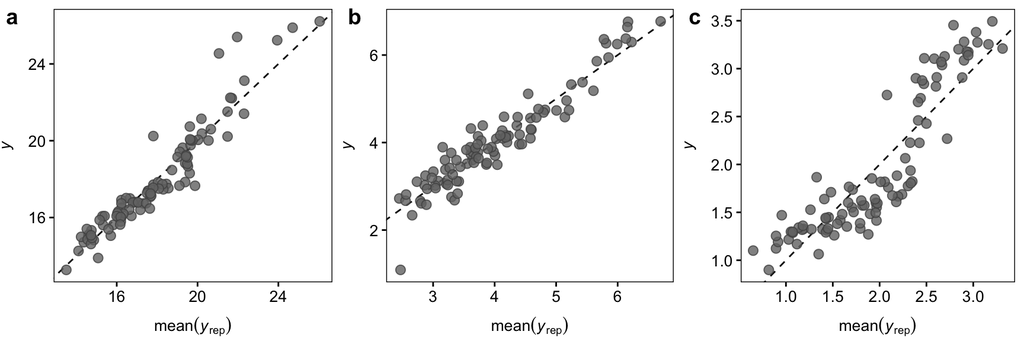

**Fig. S3** | Scatterplots of the observed data (y) vs the average simulated data (y<sub>rep</sub>) from the posterior predictive distribution for the (**a**) *T*<sub>sk</sub> model, (**b**) the TMR model, and (**c**) the TEWL model. Dashed line represents a slope of 1.

## Model output

**Table S2 - Tsk model**

**Table S2** | Summary statistics testing the effect of air temperature on the bat skin surface temperature (*T*<sub>sk</sub>). Mean parameter estimates, estimate error, and 95% Bayesian credible intervals (lower 2.5% and upper 97.5%), which includes the intercept ($\beta_0$), exposure temperature (*T*<sub>a</sub>), population (Jenolan, Yessabah), sex (female, male), the logarithm-transformed body mass, the time since onset of torpor, and the interaction between *T*<sub>a</sub> and population. Group-level effects include the standard deviations ($\sigma$) for chamber-level effects ($\sigma_{chamber}^2$), individual-level effects ($\sigma_{ID}^2$), and phylogenetic relatedness ($\sigma_{phylogeny}^2$). Heritability was calculated as $h^2 = \sigma_{phylogeny}^2 / (\sigma_{phylogeny}^2 + \sigma^2)$. The $R_{marginal}^2$ representing variance explained by fixed effects only is 68.32 ± 2.88%, while the $R_{conditional}^2$ representing variance explained by both fixed and group-level effects is 87.01 ± 1.56%.

| Parameter | Estimate | Est.Error | Q2.5 | Q97.5 |
| --- | --- | --- | --- | --- |
| **Fixed effects** |  |  |  |  |
| $\beta_0$ | 9.27 | 15.52 | -21.18 | 40.32 |
| *T*<sub>a</sub> | 0.52 | 0.05 | 0.43 | 0.63 |
| Population - Yessabah | -1.70 | 1.02 | -3.71 | 0.28 |
| Sex - Male | 0.20 | 0.91 | -1.62 | 1.99 |
| lnMass | 1.99 | 5.92 | -9.81 | 13.68 |
| Torpor onset | -0.13 | 0.15 | -0.44 | 0.17 |
| *T*<sub>a</sub>: Population - Yessabah | -0.04 | 0.06 | -0.16 | 0.08 |
| **Group-level effects** |  |  |  |  |
| $\sigma_{chamber}^2$ | 0.44 | 0.40 | 0.02 | 1.46 |
| $\sigma_{ID}^2$ | 1.57 | 0.34 | 0.99 | 2.32 |
| $\sigma_{phylogeny}^2$ | 0.61 | 0.55 | 0.02 | 2.06 |
| **Heritability** |  |  |  |  |
| $h^2$ | 0.25 | 0.24 | 0.00 | 0.81 |

**Table S3 - TMR model**

**Table S3** | Summary statistics testing the effect of air temperature on torpor metabolic rate (TMR). Mean parameter estimates, estimate error, and 95% Bayesian credible intervals (lower 2.5% and upper 97.5%), which includes the intercept ($\beta_0$), exposure temperature (*T*<sub>a</sub>), population (Jenolan, Yessabah), sex (female, male), the logarithm-transformed body mass, the time since onset of torpor, and the interaction between *T*<sub>a</sub> and population. Group-level effects include the standard deviations ($\sigma$) for chamber-level effects ($\sigma_{chamber}^2$), individual-level effects ($\sigma_{ID}^2$), and phylogenetic relatedness ($\sigma_{phylogeny}^2$). Heritability was calculated as $h^2 = \sigma_{phylogeny}^2 / (\sigma_{phylogeny}^2 + \sigma^2)$. The $R_{marginal}^2$ representing variance explained by fixed effects only is 66.31 ± 4.18%, while the $R_{conditional}^2$ representing variance explained by both fixed and group-level effects is 86.77 ± 1.56%.

| Parameter | Estimate | Est.Error | Q2.5 | Q97.5 |
| --- | --- | --- | --- | --- |
| **Fixed effects** |  |  |  |  |
| $\beta_0$ | -8.32 | 6.07 | -20.08 | 3.71 |
| *T*<sub>a</sub> | 0.14 | 0.02 | 0.10 | 0.18 |
| Population - Yessabah | -0.93 | 0.41 | -1.74 | -0.11 |
| Sex - Male | -0.04 | 0.35 | -0.74 | 0.62 |
| lnMass | 4.56 | 2.32 | -0.02 | 9.08 |
| Torpor onset | -0.07 | 0.06 | -0.19 | 0.05 |
| *T*<sub>a</sub>: Population - Yessabah | -0.03 | 0.02 | -0.08 | 0.02 |
| **Group-level effects** |  |  |  |  |
| $\sigma_{chamber}^2$ | 0.23 | 0.21 | 0.01 | 0.80 |
| $\sigma_{ID}^2$ | 0.56 | 0.17 | 0.18 | 0.89 |
| $\sigma_{phylogeny}^2$ | 0.42 | 0.35 | 0.01 | 1.32 |
| **Heritability** |  |  |  |  |
| $h^2$ | 0.41 | 0.30 | 0.00 | 0.92 |

**Table S4 - TEWL model**

**Table S4** | Summary statistics testing the effect of air temperature on torpor evaporative water loss (TEWL). Mean parameter estimates, estimate error, and 95% Bayesian credible intervals (lower 2.5% and upper 97.5%), which includes the intercept ($\beta_0$), exposure temperature (*T*<sub>a</sub>), population (Jenolan, Yessabah), sex (female, male), the logarithm-transformed body mass,the time since onset of torpor, and the interaction between *T*<sub>a</sub> and population. Group-level effects include the standard deviations ($\sigma$) for chamber-level effects ($\sigma_{chamber}^2$), individual-level effects ($\sigma_{ID}^2$), and phylogenetic relatedness ($\sigma_{phylogeny}^2$). Heritability was calculated as $h^2 = \sigma_{phylogeny}^2 / (\sigma_{phylogeny}^2 + \sigma^2)$. The $R_{marginal}^2$ representing variance explained by fixed effects only is 73.62 ± 2.62%, while the $R_{conditional}^2$ representing variance explained by both fixed and group-level effects is 77.36 ± 2.25%.

| Parameter | Estimate | Est.Error | Q2.5 | Q97.5 |
| --- | --- | --- | --- | --- |
| **Fixed effects** |  |  |  |  |
| $\beta_0$ | -1.77 | 2.17 | -6.03 | 2.49 |
| *T*<sub>a</sub> | 0.13 | 0.02 | 0.09 | 0.16 |
| Population - Yessabah | -0.47 | 0.25 | -0.96 | 0.02 |
| Sex - Male | 0.20 | 0.13 | -0.05 | 0.45 |
| lnMass | 0.96 | 0.83 | -0.67 | 2.60 |
| Torpor onset | -0.04 | 0.02 | -0.08 | 0.01 |
| *T*<sub>a</sub>: Population - Yessabah | 0.05 | 0.02 | 0.01 | 0.09 |
| **Group-level effects** |  |  |  |  |
| $\sigma_{chamber}^2$ | 0.10 | 0.08 | 0.00 | 0.31 |
| $\sigma_{ID}^2$ | 0.08 | 0.06 | 0.00 | 0.21 |
| $\sigma_{phylogeny}^2$ | 0.15 | 0.09 | 0.01 | 0.35 |
| **Heritability** |  |  |  |  |
| $h^2$ | 0.15 | 0.13 | 0.00 | 0.49 |

**Table S5 - TMR + Tsk model**

| Parameter | Estimate | Est.Error | Q2.5 | Q97.5 |
| --- | --- | --- | --- | --- |
| **Fixed effects** |  |  |  |  |
| $\beta_0$ | -10.10 | 4.44 | -18.87 | -1.32 |
| *T*<sub>a</sub> | 0.03 | 0.03 | -0.02 | 0.08 |
| Population - Yessabah | -0.53 | 0.33 | -1.18 | 0.11 |
| Sex - Male | -0.08 | 0.25 | -0.58 | 0.41 |
| lnMass | 4.05 | 1.70 | 0.70 | 7.43 |
| *T*<sub>sk</sub> | 0.21 | 0.04 | 0.14 | 0.29 |
| Torpor onset | -0.04 | 0.05 | -0.14 | 0.05 |
| *T*<sub>a</sub>: Population - Yessabah | -0.02 | 0.02 | -0.06 | 0.02 |
| **Group-level effects** |  |  |  |  |
| $\sigma_{chamber}^2$ | 0.25 | 0.20 | 0.01 | 0.76 |
| $\sigma_{ID}^2$ | 0.38 | 0.12 | 0.14 | 0.62 |
| $\sigma_{phylogeny}^2$ | 0.30 | 0.23 | 0.01 | 0.88 |
| **Heritability** |  |  |  |  |
| $h^2$ | 0.36 | 0.27 | 0.00 | 0.86 |

# Figures

Code to produce the main document figures is provided below. Figures produced were further modified in [Adobe Illustrator](https://www.adobe.com/au/products/illustrator.html) for publication.

## Figure 1 - Study sites

Download elevation map from `rnaturalearth` and convert to dataframe.

```r
# Australia map
aus_map <- rnaturalearth::ne_states(country = "Australia", returnclass = "sf")

# Elevation map
aus_elev_sp <- elevatr::get_elev_raster(locations = aus_map, z = 7, clip = "locations")  # 1km resolution or 30 arc sec
# aus_elev_sp <- readRDS(file.path(data_path, '/aus_elev_sp.rds'))

aus_elev_df <- raster::as.data.frame(aus_elev_sp, xy = TRUE)
colnames(aus_elev_df)[3] <- "elevation"
aus_elev_df <- aus_elev_df[complete.cases(aus_elev_df), ]  # Remove NAs

aus_elev_df_2 <- aus_elev_df %>%
    dplyr::filter(x >= 143 & y <= -24)
```

Produce eastcoast map with study sites, and temperature profiles.

```r
# Miniopterus distribution
range_map <- raster::shapefile(file.path(data_path, "data/Miniopterus_orianae_oceanensis/Miniopterus_orianae_oceanensis.shp"))
range_map <- sp::spTransform(range_map, raster::crs("+proj=longlat +datum=WGS84 +no_defs"))

# Sites
resp_sites_df <- data.frame(x = c(150.018564, 152.688690),
                            y = c(-33.803127, -31.093943),
                            site = c("Jenolan","Yessabah"))

map_plot <- ggplot() +
  geom_polygon(data = range_map, aes(x = long, y = lat, group = group), colour = NA, fill = "#f595a6") +
  geom_raster(data = aus_elev_df_2, aes(x = x, y = y, fill = elevation), alpha = 0.5, show.legend = F) +
  scale_fill_gradient2(low = "white", mid = "white", high = "black", midpoint = 0) +
  geom_sf(data = aus_map, color = "#8C8C8C", fill = NA) +
  geom_point(data = resp_sites_df, aes(x = x, y = y), shape = 21, colour = "black", fill = "white", size = 3) +
  xlim(143, 155) + ylim(-39.5, -24) +
  coord_sf() +
  theme_void()

# Load all files
HOBO_list  <- list.files(path = file.path(data_path, "data/"), pattern = "\\HOBO.csv$", full.names = T)
HOBO_list2 <- data.frame(file_name = HOBO_list, id = as.character(1:length(HOBO_list))) # id for joining

HOBO_dat <- HOBO_list %>%
  lapply(read_csv) %>% # read all files at once
  dplyr::bind_rows(.id = "id") %>% # bind all tables into one object, and give id for each
  data.frame() %>%
  dplyr::mutate(date_time = as.POSIXct(date_time, format = "%m/%d/%Y %H:%M"),
                date      = as.POSIXct(date_time, format = "%m/%d/%Y"),
                time      = strftime(date_time, format = "%H:%M:%S"),
                jul_day   = as.POSIXlt(date_time)$yday,
                month     = format(as.Date(date_time, format = "%m/%d/%Y"),"%m"),
                month_cat = format(as.Date(date_time, format = "%m/%d/%Y"),"%B"),
                location = factor(location, levels = c("EXT", "deep")))

temp_plot <- ggplot() +
  geom_line(data = HOBO_dat %>% dplyr::filter(location == "EXT"),
            aes(x = jul_day, y = air_temp), size = 0.5, colour = "#f595a6") +
  geom_line(data = HOBO_dat %>% dplyr::filter(location == "deep"),
            aes(x = jul_day, y = air_temp), size = 1.2, colour = "black") +
  ylab("Air temperature (°C)") + xlab(NULL) +
  mytheme() +
  theme(legend.position = "bottom") +
  facet_wrap(~ site, ncol = 1)

cowplot::plot_grid(map_plot, temp_plot, ncol = 2, rel_widths = c(1, 0.5))
```

## Figure 2 - *T*<sub>sk</sub>, TMR, and TEWL

```r
Tsk_me <- as.data.frame(ggeffects::ggpredict(Tsk_mod, terms = c("temp_exp", "pop", "tor_start [5]", "lnMass [2.7]")))

Tsk_plot <- ggplot() +
  # raw data
  geom_line(data = torpor_dat, aes(x = temp_exp, y = Tsk_C, group = ID),
            colour = "lightgrey",
            alpha = 0.5,
            position = position_dodge(0.2)) +
  geom_point(data = torpor_dat,
             aes(x = temp_exp, y = Tsk_C, shape = pop),
             size = 1, position = position_dodge(0.2), alpha = 0.5) +
  # summary data
  geom_errorbar(data = Tsk_me, aes(x = x, ymin = conf.low, ymax = conf.high, group = group),
                width = 0.1, position = position_dodge(0.2)) +
  geom_line(data = Tsk_me, aes(x = x, y = predicted, group = group, linetype = group), position = position_dodge(0.2)) +
  geom_point(data = Tsk_me, aes(x = x, y = predicted, shape = group, fill = group), size = 3, position = position_dodge(0.2)) +
  scale_shape_manual(values = c(21, 24)) +
  scale_fill_manual(values = c("white", "black")) +
  xlab(expression(italic("T")["a"]~"(°C)")) +
  ylab(expression(italic("T")["sk"]~"(°C)")) +
  mytheme()

MR_me <- as.data.frame(ggeffects::ggpredict(MR_mod, terms = c("temp_exp", "pop", "tor_start [5]", "lnMass [2.7]"))) %>%
  dplyr::mutate(est = exp(predicted),
                low = exp(conf.low),
                high = exp(conf.high))

MR_plot <- ggplot() +
  # raw data
  geom_line(data = torpor_dat, aes(x = temp_exp, y = MR_J_h, group = ID),
            colour = "lightgrey",
            alpha = 0.5,
            position = position_dodge(0.2)) +
  geom_point(data = torpor_dat,
             aes(x = temp_exp, y = MR_J_h, shape = pop),
             size = 1, position = position_dodge(0.2), alpha = 0.5) +
  # summary data
  geom_errorbar(data = MR_me, aes(x = x, ymin = low, ymax = high, group = group),
                width = 0.1, position = position_dodge(0.2)) +
  geom_line(data = MR_me, aes(x = x, y = est, group = group, linetype = group), position = position_dodge(0.2)) +
  geom_point(data = MR_me, aes(x = x, y = est, shape = group, fill = group), size = 3, position = position_dodge(0.2)) +
  scale_shape_manual(values = c(21, 24)) +
  scale_fill_manual(values = c("white", "black")) +
  xlab(expression(italic("T")["a"]~"(°C)")) +
  ylab(expression("TMR (J h"^"-1"*")")) +
  scale_y_continuous(breaks = c(1, 10, 25, 50, 100, 200, 400, 800), trans = "sqrt") +
  mytheme()

EWL_me <- as.data.frame(ggeffects::ggpredict(EWL_mod, terms = c("temp_exp", "pop", "tor_start [5]", "lnMass [2.7]"))) %>%
  dplyr::mutate(est = exp(predicted),
                low = exp(conf.low),
                high = exp(conf.high))

EWL_plot <- ggplot() +
  # raw data
  geom_line(data = torpor_dat, aes(x = temp_exp, y = EWL_mg_h, group = ID),
            colour = "lightgrey",
            alpha = 0.5,
            position = position_dodge(0.2)) +
  geom_point(data = torpor_dat,
             aes(x = temp_exp, y = EWL_mg_h, shape = pop),
             size = 1, position = position_dodge(0.2), alpha = 0.5) +
  # summary data
  geom_errorbar(data = EWL_me, aes(x = x, ymin = low, ymax = high, group = group),
                width = 0.1, position = position_dodge(0.2)) +
  geom_line(data = EWL_me, aes(x = x, y = est, group = group, linetype = group), position = position_dodge(0.2)) +
  geom_point(data = EWL_me, aes(x = x, y = est, shape = group, fill = group), size = 3, position = position_dodge(0.2)) +
  scale_shape_manual(values = c(21, 24)) +
  scale_fill_manual(values = c("white", "black")) +
  xlab(expression(italic("T")["a"]~"(°C)")) +
  ylab(expression("TEWL (mg H"["2"]*"O"~"h"^"-1"*")")) +
  scale_y_continuous(breaks = c(1, 2.5, 5, 10, 20, 30), trans = "sqrt") +
  mytheme()

MR_me2 <- as.data.frame(ggeffects::ggpredict(MR_mod2, terms = c("Tsk_C", "pop", "tor_start [5]", "lnMass [2.7]"))) %>%
  dplyr::mutate(est = exp(predicted),
                low = exp(conf.low),
                high = exp(conf.high))

MR_plot2 <- ggplot() +
  # raw data
  geom_line(data = torpor_dat, aes(x = Tsk_C, y = MR_J_h, group = ID),
            colour = "lightgrey",
            alpha = 0.5,
            position = position_dodge(0.2)) +
  geom_point(data = torpor_dat,
             aes(x = Tsk_C, y = MR_J_h, shape = pop),
             size = 1, position = position_dodge(0.2), alpha = 0.5) +
  # summary data
  geom_ribbon(data = MR_me2, aes(x = x, ymin = low, ymax = high,  group = group), alpha = 0.1) +
  geom_line(data = MR_me2, aes(x = x, y = est, group = group, linetype = group)) +
  scale_shape_manual(values = c(21, 24)) +
  scale_fill_manual(values = c("white", "black")) +
  xlab(expression(italic("T")["sk"]~"(°C)")) +
  ylab(expression("MR (J h"^"-1"*")")) +
  mytheme()

cowplot::plot_grid(MR_plot + theme(legend.position = "none"),
                   EWL_plot + theme(legend.position = "none"),
                   Tsk_plot + theme(legend.position = "none"),
                   MR_plot2 + theme(legend.position = "none"),
                   nrow = 2, labels = c('a', 'b', 'c', 'd'))
```

## Figure 3 - Phylogeny

```r
MR_mod_post  <- posterior_samples(MR_mod) # extract posterior
EWL_mod_post <- posterior_samples(EWL_mod) # extract posterior

# Loop to extract within ID-level posterior of intercept
ID_unique  <- sort(unique(torpor_dat$ID)) # pop ID names
out_list   <- vector(mode = 'list', length = length(ID_unique))
for (j in seq_along(ID_unique)) {
  out_list[[j]]                 <- data.frame(matrix(NA, nrow(MR_mod_post), 1))
  dat_names                     <-  paste0(ID_unique[j])
  names(out_list[[j]])          <-  dat_names
  out_list[[j]][, dat_names[1]] <-  MR_mod_post[, paste0('r_ID[', ID_unique[j], ',Intercept]')]
}

MR_Int_out  <- do.call('cbind.data.frame', out_list)
MR_Int_post <- sample_n(MR_Int_out, 4000) # Extract 4000 random rows

out_list <- vector(mode = 'list', length = length(ID_unique))
for (j in seq_along(ID_unique)) {
  out_list[[j]]                 <- data.frame(matrix(NA, nrow(EWL_mod_post), 1))
  dat_names                     <-  paste0(ID_unique[j])
  names(out_list[[j]])          <-  dat_names
  out_list[[j]][, dat_names[1]] <-  EWL_mod_post[, paste0('r_ID[', ID_unique[j], ',Intercept]')]
}

EWL_Int_out  <- do.call('cbind.data.frame', out_list)
EWL_Int_post <- sample_n(EWL_Int_out, 4000) # Extract 4000 random rows

# Tidy data
MR_Int_post_long <- MR_Int_post %>%
  tidyr::pivot_longer(cols = everything(), names_to = "ID", values_to = "Intercept")

EWL_Int_post_long <- EWL_Int_post %>%
  tidyr::pivot_longer(cols = everything(), names_to = "ID", values_to = "Intercept")

MR_Int_post_sum <- MR_Int_post_long %>%
  dplyr::group_by(ID) %>%
  dplyr::summarise(mean_MR = mean(Intercept))

EWL_Int_post_sum <- EWL_Int_post_long %>%
  dplyr::group_by(ID) %>%
  dplyr::summarise(mean_EWL = mean(Intercept))

phylo_dat <- torpor_dat %>%
  dplyr::group_by(ID_gene, ID, sex, pop) %>%
  summarise(mean_mass = mean(mass_g))

x <- tidytree::as_tibble(pruned_tree_cal)
y <- dplyr::full_join(phylo_dat, MR_Int_post_sum, by = 'ID')
y <- dplyr::full_join(y, EWL_Int_post_sum, by = 'ID')

tree_dat  <- tidytree::as.treedata(dplyr::full_join(x, y %>% rename(label = ID_gene), by = 'label'))

tree_plot <- ggtree::ggtree(tree_dat) +
  ggtree::geom_tippoint(aes(shape = pop, fill = pop), size = 2, show.legend = F) +
  scale_shape_manual(values = c(21, 24)) +
  scale_fill_manual(values = c("white", "black"))

tree_plot2 <- tree_plot + ggtreeExtra::geom_fruit(geom = geom_bar,
                                    mapping = aes(x = mean_MR, fill = pop),
                                    colour = "black",
                                    size = 0.1,
                                    stat = "identity",
                                    orientation = "y",
                                    axis.params = list(axis = "x", text.size = 3),
                                    offset = 0.3,
                                    pwidth = 0.4,
                                    show.legend = F)

tree_plot2 + ggtreeExtra::geom_fruit(geom = geom_bar,
                                     mapping = aes(x = mean_EWL, fill = pop),
                                     colour = "black",
                                     size = 0.1,
                                     stat = "identity",
                                     orientation = "y",
                                     axis.params = list(axis = "x", text.size = 3),
                                     offset = 0.3,
                                     pwidth = 0.4,
                                     show.legend = F)
```

# Reviewer comments

The Associate Editor requested to provide supporting evidence for the sentence “*TEWL may exhibit plasticity in response to local environmental conditions, independent of MR, as observed in arid-adapted species*” by analysing the TEWL model with the inclusion of the TMR as a fixed effect.

```r
EWL_MR_mod <- brms::brm(lnEWL ~ temp_exp * pop + sex + lnMass + lnMR + tor_start +
                      (1 | ID) + (1 | chamber_n) + (1 | gr(ID_gene, cov = phylo)),
                    data    = torpor_dat,
                    data2   = list(phylo = phylo_cor),
                    chains  = 4, cores = 4,
                    iter    = 1e4, warmup = 5e3,
                    control = list(adapt_delta = 0.99))
```

### Table S6 - TEWL model (accounting for TMR)

| Parameter | Estimate | Est.Error | Q2.5 | Q97.5 |
| --- | --- | --- | --- | --- |
| **Fixed effects** |  |  |  |  |
| $\beta_0$ | 0.44 | 2.18 | -3.80 | 4.77 |
| *T*<sub>a</sub> | 0.09 | 0.02 | 0.05 | 0.13 |
| Population - Yessabah | -0.36 | 0.24 | -0.82 | 0.10 |
| Sex - Male | 0.20 | 0.13 | -0.06 | 0.45 |
| lnMass | -0.17 | 0.86 | -1.88 | 1.49 |
| lnMR | 0.24 | 0.07 | 0.11 | 0.37 |
| Torpor onset | -0.02 | 0.02 | -0.07 | 0.02 |
| *T*<sub>a</sub>: Population - Yessabah | 0.06 | 0.02 | 0.02 | 0.10 |
| **Group-level effects** |  |  |  |  |
| $\sigma_{chamber}^2$ | 0.11 | 0.09 | 0.00 | 0.34 |
| $\sigma_{ID}^2$ | 0.08 | 0.06 | 0.00 | 0.21 |
| $\sigma_{phylogeny}^2$ | 0.12 | 0.08 | 0.01 | 0.31 |
| **Heritability** |  |  |  |  |
| $h^2$ | 0.12 | 0.13 | 0.00 | 0.46 |

# References

**Gelman, A. and Rubin, D. B.** (1992). [Inference from iterative simulation using multiple sequences](https://doi.org/10.1214/ss/1177011136). *Statistical Science* **7**, 457–472.

**Lighton, J. R. B.** (2019). *Measuring metabolic rates: A manual for scientists*. ed. 2. Oxford University Press.

**Mijangos, J. L., Berry, O. F., Pacioni, C. and Georges, A.** (2022). [dartR v2: An accessible genetic analysis platform for conservation, ecology and agriculture](https://doi.org/10.1111/2041-210X.13918). *Methods in Ecology and Evolution* **18**, 691–699.

**Nguyen, L.-T., Schmidt, H. A., Von Haeseler, A. and Minh, B. Q.** (2015). [IQ-TREE: A fast and effective stochastic algorithm for estimating maximum-likelihood phylogenies](https://doi.org/10.1093/molbev/msu300). *Molecular Biology and Evolution* **32**, 268–274.

**Stull, R. B.** (2000). Meteorology for scientists and engineers: A technical companion book with ahrens’ meteorology today.

## Session Information

**R version 4.5.0 (2025-04-11)**

**Platform:** aarch64-apple-darwin20

**attached base packages:** *stats*, *graphics*, *grDevices*, *utils*, *datasets*, *methods* and *base*

**other attached packages:** *MCMCglmm(v.2.36)*, *coda(v.0.19-4.1)*, *Matrix(v.1.7-4)*, *rstan(v.2.32.7)*, *StanHeaders(v.2.32.10)*, *brms(v.2.23.0)*, *Rcpp(v.1.1.0)*, *raster(v.3.6-32)*, *elevatr(v.0.99.1)*, *sp(v.2.2-0)*, *sf(v.1.0-21)*, *rnaturalearthhires(v.1.0.0.9000)*, *rnaturalearth(v.1.1.0)*, *ggtreeExtra(v.1.18.1)*, *ggtree(v.3.16.3)*, *ape(v.5.8-1)*, *dartR.base(v.1.0.7)*, *dartR.data(v.1.0.8)*, *adegenet(v.2.1.11)*, *ade4(v.1.7-23)*, *cowplot(v.1.2.0)*, *lubridate(v.1.9.4)*, *forcats(v.1.0.1)*, *stringr(v.1.5.2)*, *dplyr(v.1.1.4)*, *purrr(v.1.1.0)*, *readr(v.2.1.5)*, *tidyr(v.1.3.1)*, *tibble(v.3.3.0)*, *ggplot2(v.4.0.0)*, *tidyverse(v.2.0.0)* and *knitr(v.1.50)*